# SITUACIÓN DEL MERCADO DE TRABAJO

Martin Gonzalez-Rozada.  
Director de la Maestría en Econometría del Departamento de Economía de la [Universidad Torcuato Di Tella](https://www.utdt.edu/).

Segundo Trimestre 2024

**En el segundo trimestre de 2024, en el total de los 31 aglomerados urbanos capturados por la Encuesta Permanente de Hogares (EPH) la tasa de actividad se estimó en 48.5 por ciento, la tasa de empleo en 44.8 por ciento y la tasa de desocupación en 7.6 por ciento.**

**Figura 1. Principales Tasas del Mercado de Trabajo. Total de Aglomerados**

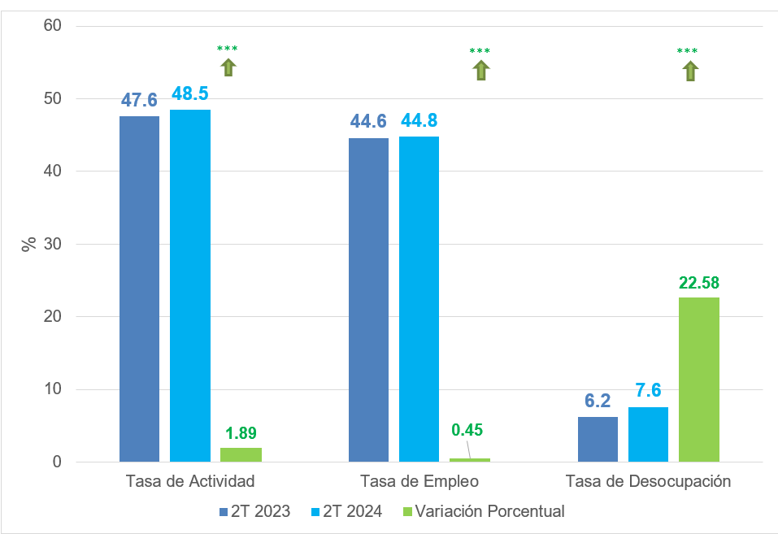

Fuente: elaboración propia a partir de la Encuesta Permanente de Hogares (EPH). * Diferencia significativa con p < 0,10. ** Diferencia significativa con p < 0,05. *** Diferencia significativa con p < 0,01.

**Principales Tasas del Mercado de Trabajo (Total de Aglomerados)**

**En el segundo trimestre de 2024, la tasa de empleo aumentó 0.2 puntos porcentuales en el total de aglomerados capturados por la EPH en comparación con el segundo trimestre de 2023.** Como sucedió con la tasa de actividad, esta variación es estadísticamente significativa y está explicada por un aumento de 1.1 por ciento en la tasa de empleo en los aglomerados de más de 500 mil habitantes, mientras que en los aglomerados de menos de 500 mil habitantes la tasa de empleo cayó casi 1 punto porcentual (Cuadro 3). **Este aumento en la tasa de empleo en el total de aglomerados implicó que alrededor de 190 mil personas se ocuparan entre el segundo trimestre de 2023 y el segundo de 2024** (Cuadro 4). El aumento en la ocupación estuvo asociado al crecimiento del empleo de mujeres mayores de 29 años y hombres mayores de 64 años; en trabajadores con secundaria incompleta y con educación universitaria completa; en trabajadores por cuenta propia, en trabajadores asalariados formales y del sector privado; en trabajadores cuya calificación es técnica o profesional y mayormente en actividades primarias, hoteles y restaurantes, transporte almacenamiento y comunicaciones, servicios sociales y de salud y servicio doméstico (Cuadro 7).

**La tasa de desocupación aumentó 1.4 puntos porcentuales entre el segundo trimestre de 2023 y el segundo de 2024.** A diferencia de la tasa de actividad y la de empleo, **la tasa de desocupación aumentó tanto en los aglomerados de más de 500 mil habitantes como en los de menos de 500 mil habitantes.** En los aglomerados del interior del país la tasa de desocupación aumentó 17.5 por ciento en la comparación interanual (Cuadro 5). **Como consecuencia del aumento en la tasa de desocupación más de 200 mil personas ingresaron en el desempleo entre el segundo trimestre de 2023 y el segundo de 2024** (Cuadro 6). **El número total de desocupados en el total de aglomerados de la EPH en el segundo trimestre de 2024 es de 1.1 millones de personas.** La tasa de desocupación aumentó en términos interanuales en trabajadores que tenían una ocupación anterior, en trabajadores cuya ocupación anterior era de asalariados, trabajadores del sector público y trabajadores con calificación de operativos. Por otro lado, la tasa de desocupación cayó para aquellos trabajadores con educación universitaria, para aquellos que eran no asalariados y no calificados, además de aquellos cuya última ocupación era en el sector de la construcción, industria manufacturera y servicio doméstico (Cuadro 8).

**Principales Tasas del Mercado de Trabajo por Área Geográfica**

**Región Cuyo:** la tasa de actividad se incrementó 0.4 puntos porcentuales entre el segundo trimestre de 2023 y el segundo de 2024. El aumento fue impulsado por los aglomerados del Gran Mendoza y el Gran San Juan, donde la tasa de actividad aumentó entre 0.7 y 1 punto porcentual. Por otro lado, en el Gran San Luis la tasa de actividad retrocedió 2.2 puntos porcentuales en la comparación interanual (Cuadro 1). La tasa de empleo cayó 0.1 puntos porcentuales entre el segundo trimestre de 2023 y el segundo de 2024 impulsada por la caída de casi 3 puntos porcentuales en el aglomerado del Gran San Luis (Cuadro 3). La tasa de desocupación pasó de 4.1 por ciento en el segundo trimestre de 2023 a 5.1 por ciento en el segundo de 2024. Este aumento fue generalizado en los tres aglomerados que componen la región (Cuadro 5). En el segundo trimestre de 2024 había más de 45 mil personas desocupadas en la región de Cuyo (Cuadro 6).

**Región Noroeste:** la tasa de actividad cayó de 46.1 a 46.0 por ciento entre el segundo trimestre de 2023 y el segundo de 2024. Esta caída fue impulsadoa por el comportamiento de la tasa de actividad de los aglomerados de Gran Catamarca, Gran Tucumán-Tafí Viejo, La Rioja y Salta. En Jujuy-Palpalá la tasa de actividad creció 2.2 puntos porcentuales y en Santiago del Estero-La Banda permaneció estable (Cuadro 1). La tasa de empleo cayó 0.2 puntos porcentuales en la comparación interanual. El comportamiento de la tasa de empleo fue heterogéneo en los aglomerados que integran la región, aumentando en Jujuy-Palpalá y Santiego del Estero-La Banda y cayendo en el resto de los aglomerados (Cuadro 3). La tasa de desocupación aumentó 0.1 puntos porcentuales alcanzando 5.2 por ciento en el segundo trimestre de 2024. Este pequeño aumento fue el resultado de incrementos en los aglomerados de Gran Tucumán-Tafí Viejo, La Rioja y Salta y de caídas en el desempleo en Jujuy-Palpalá y Santiago del Estero-La Banda (Cuadro 5).

**Región Pampeana:** la tasa de actividad cayó 0.1 puntos porcentuales en la comparación interanual impulsada por caídas en la tasa de actividad de los aglomerados de Bahía Blanca-Cerri, Concordia, Gran La Plata, Gran Paraná, Gran Santa Fé y San Nicolás-Villa Constitución (Cuadro 1). La tasa de empleo pasó de 45.9 por ciento en el segundo trimestre de 2023 a 45.4 por ciento en el segundo de 2024. Esta caída en la tasa de empleo se explica por una caída casi generalizada del empleo en todos los aglomerados que integran la región (Cuadro 3). La tasa de desocupación aumentó casi 1 punto porcentual entre el segundo trimestre de 2023 y el segundo de 2024. El aumento fue impulsado por incrementos de la tasa de desocupación en los aglomerados de Bahía Blanca-Cerri, Gran La Plata, Gran Rosario, y Santa Rosa-Toay (Cuadro 5). En esta región el número de desocupados alcanza casi 240 mil personas en el segundo trimestre de 2024 (Cuadro 6).

**Región Patagonia:** La tasa de actividad cayó 1.3 por ciento entre el segundo trimestre de 2023 y el segundo de 2024. El comportamiento de la tasa de actividad fue heterogéneo en los aglomerados que integran la región, aumentando en Neuquén-Plottier, Rawson-Trelew y Viedma-Carmen de Patagones y cayendo en el resto de los aglomerados (Cuadro 1). La tasa de empleo cayó 1 punto porcentual en la comparación interanual impulsada por caídas del empleo en Comodorao Rivadavia-Rada Tilly, Río Gallegos, Ushuaia-Río Grande y Rawson-Trelew (Cuadro 3). La tasa de desocupación pasó de 4.3 por ciento en el segundo trimestre de 2023 a 5.4 por ciento en el segundo trimestre de 2024. El aumento de la desocupación se dió en casi todos los aglomerados de la región con la única excepción del aglomerado Viedma-Carmen de Patagones donde la tasa de desocupación cayó 0.2 puntos porcentuales (Cuadro 5).

**Cuadro 1: evolución de la tasa de actividad por aglomerado**

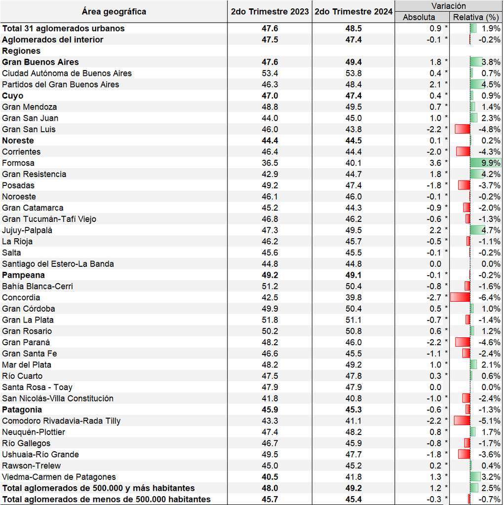

Nota: * indica que la variación es estadísticamente significativa al 5%.

**Cuadro 2: personas que pertenecen a la fuerza de trabajo**

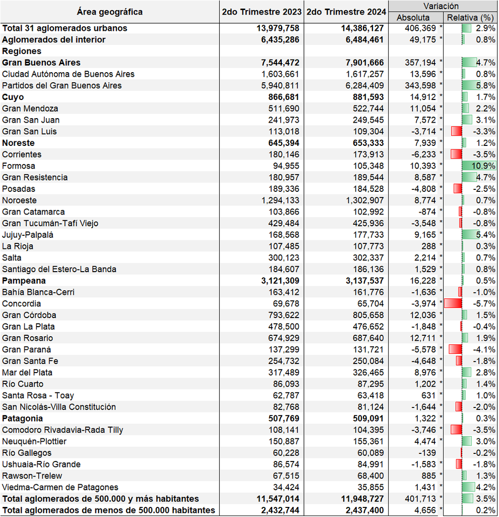

Nota: * indica que la variación es estadísticamente significativa al 5%.

**Cuadro 3: evolución de la tasa de empleo por aglomerado**

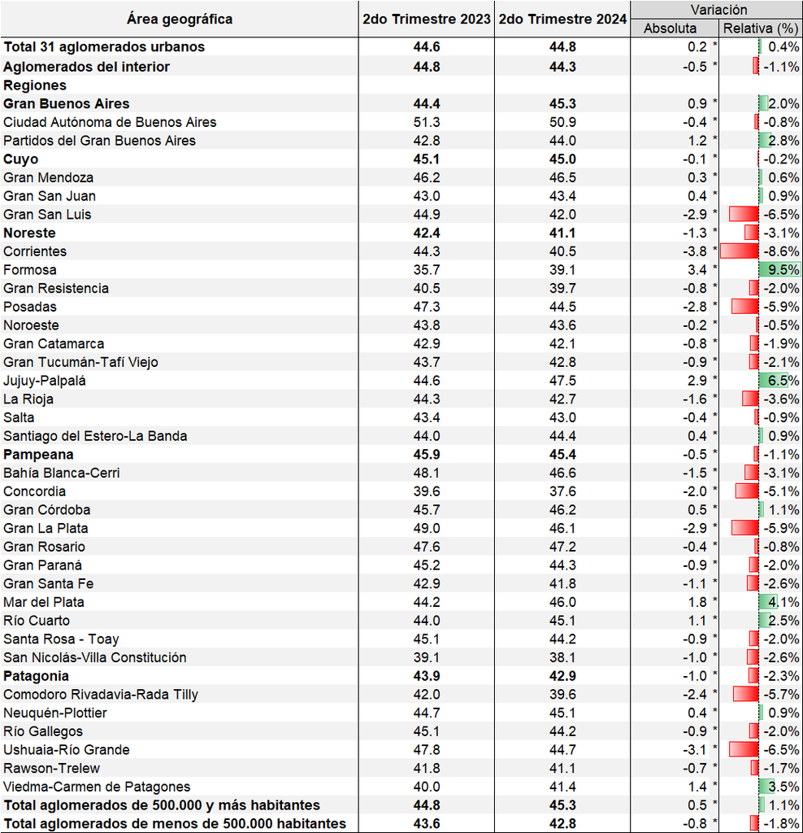

Nota: * indica que la variación es estadísticamente significativa al 5%.

**Cuadro 4: personas ocupadas**

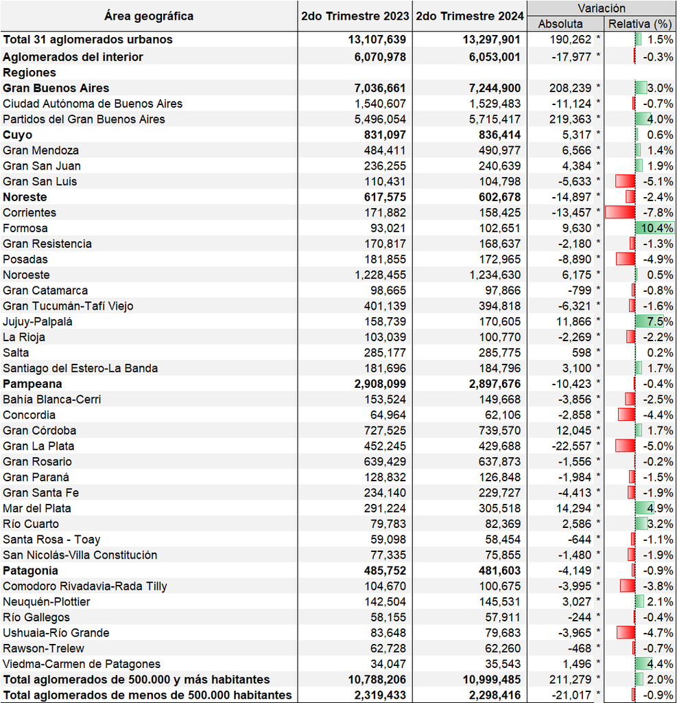

Nota: * indica que la variación es estadísticamente significativa al 5%.

**Cuadro 5: evolución de la tasa de desocupación por aglomerado**

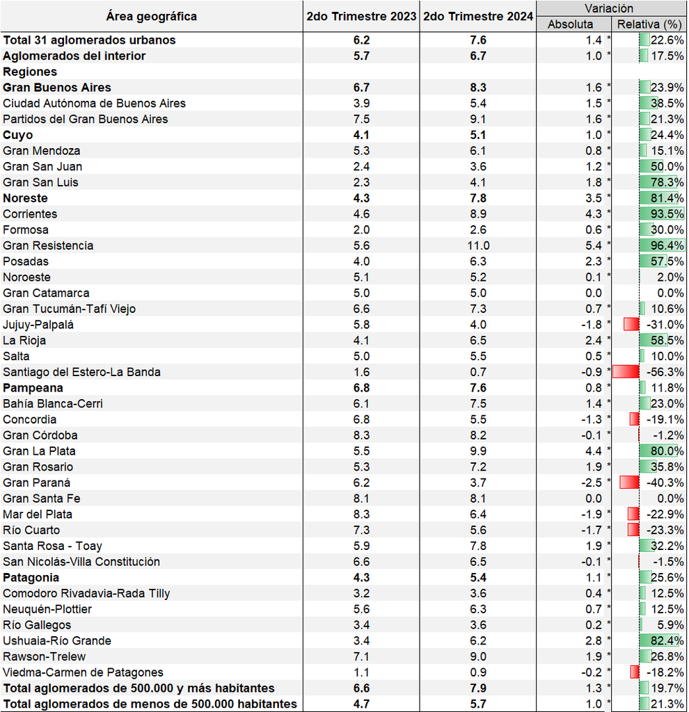

Nota: * indica que la variación es estadísticamente significativa al 5%.

**Cuadro 6: personas desempleadas**

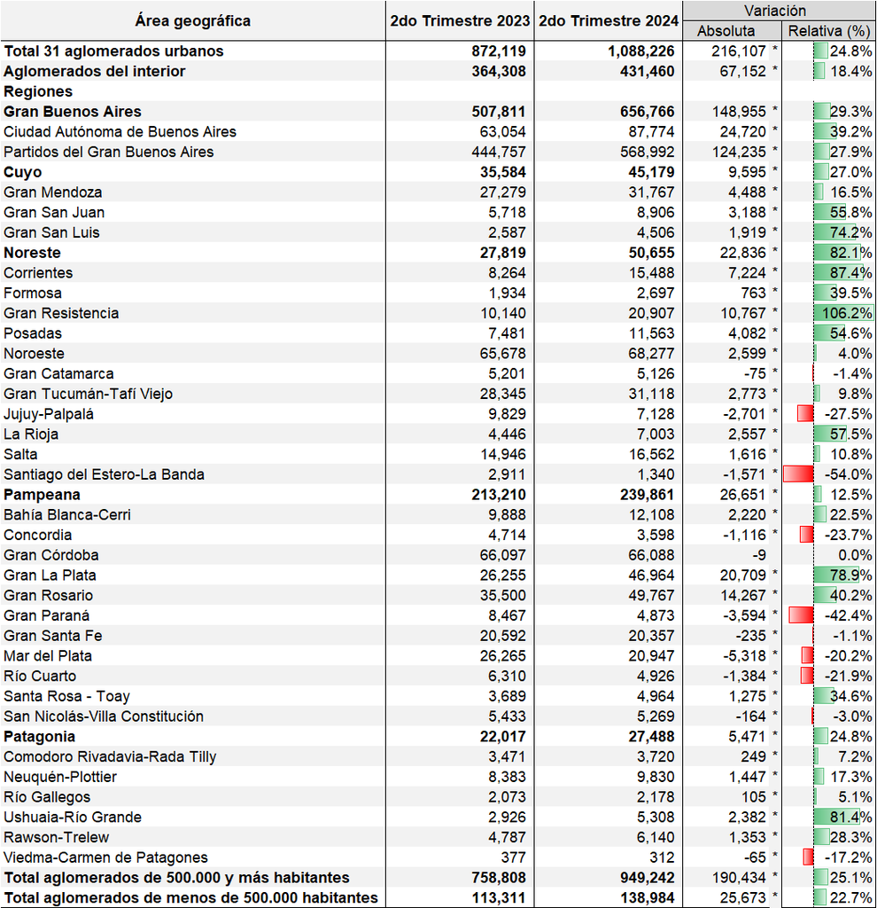

Nota: * indica que la variación es estadísticamente significativa al 5%.

**Cuadro 7: características de las personas ocupadas**

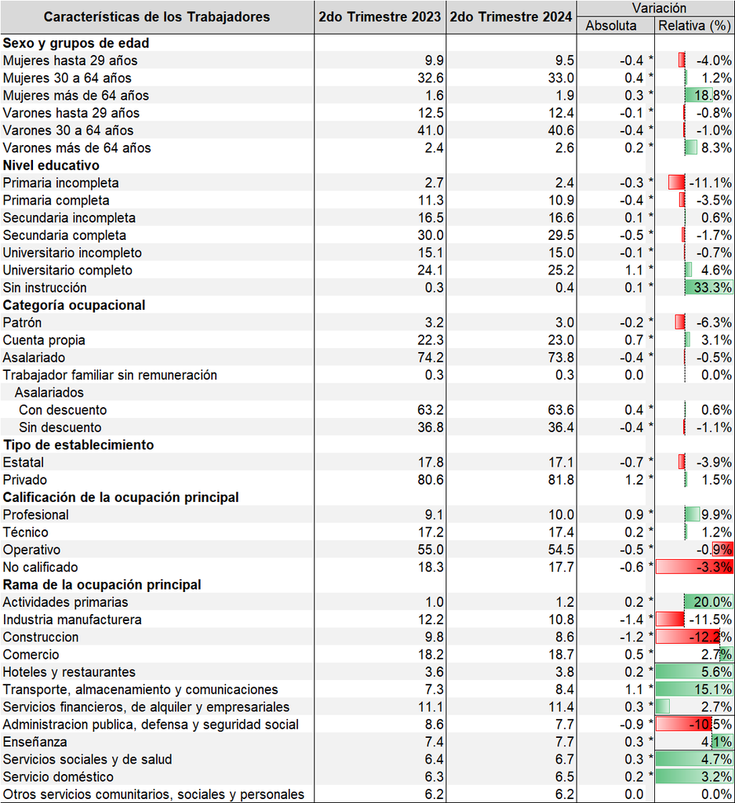

Nota: * indica que la variación es estadísticamente significativa al 5%.

**Cuadro 8: características de las personas desocupadas**

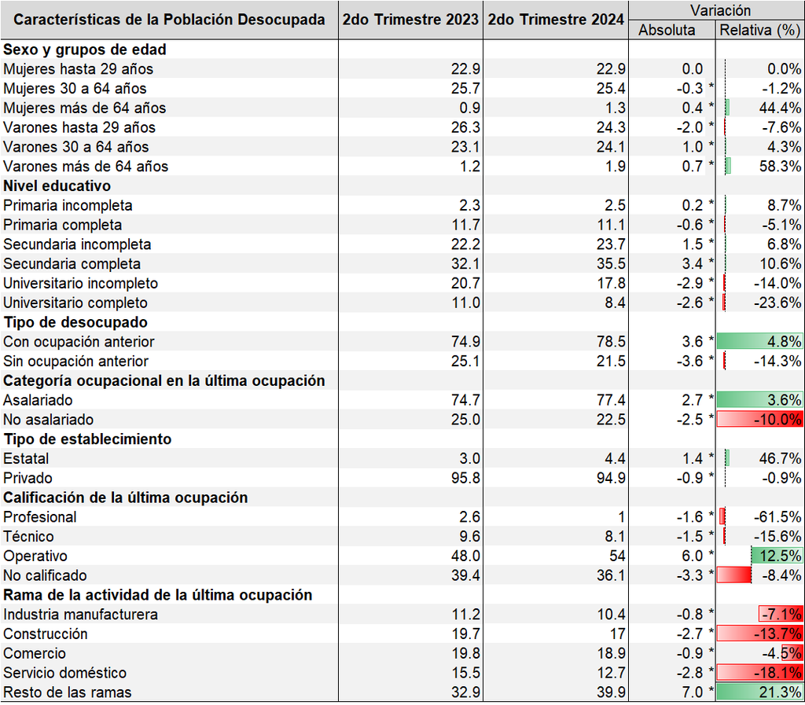

Nota: * indica que la variación es estadísticamente significativa al 5%.